# Проверка гипотез для крупного интернет-магазина

**Описание:** Вместе с отделом маркетинга мы подготовили список гипотез для увеличения выручки. Мы приоритизируем гипотезы, запустим A/B-тест и проанализируем его результаты.

**Цель исследования**

- Приоритизация гипотез
- Анализ A/B-теста
- Выводы по результатам теста

**Входные данный**

- `hypothesis.csv` - информация о гипотезах по увеличению выручки интернет-магазина
- `orders.csv` - информацию о заказах
- `visitors.csv` - информацию о визитах

**Ход исследования**

1. **Обзор данных.**
2. **Приоритизация гипотез**
3. **Анализ A/B-теста**
4. **Выводы**

### Обзор данных.

Загружаем данные и подготовим их к анализу.

**Пути к файлам**

- гипотезах: `/datasets/hypothesis.csv`
- заказы: `/datasets/orders.csv`
- визитах: `/datasets/visitors.csv`

### Импорт библиотек и загрузка данных

`pandas` - библиотека для загрузки и обработки данных

`matplotlib.pyplot` - библиотека для работы с графиками

`datetime` - библиотека для работой с датой

`numpy` - библиотека высокоуровневых математических функций

`scipy.stats` - библиотека для работы со статистический анализом данных

```python
import pandas as pd
import numpy as np
import datetime as dt
import scipy.stats as stats
import matplotlib.pyplot as plt
```

# Загрузим файлы из папки /datasets и сохраним в переменные

Выведем первые 5 строк таблиц и общую информацию:

```python
try:
    hypothesis = pd.read_csv('/datasets/hypothesis.csv')
    orders = pd.read_csv('/datasets/orders.csv')
    visitors = pd.read_csv('/datasets/visitors.csv')
    display('Загрузка онлайн')
except:
    hypothesis = pd.read_csv('hypothesis.csv')
    orders = pd.read_csv('orders.csv')
    visitors = pd.read_csv('visitors.csv')
    display('Загрузка офлайн')
```

```
'Загрузка офлайн'
```

```python
hypothesis.info()
orders.info()
visitors.info()
```

```
<class 'pandas.core.frame.DataFrame'>
RangeIndex: 9 entries, 0 to 8
Data columns (total 5 columns):
 #   Column      Non-Null Count  Dtype
---  ------      --------------  -----
 0   Hypothesis  9 non-null      object
 1   Reach       9 non-null      int64
 2   Impact      9 non-null      int64
 3   Confidence  9 non-null      int64
 4   Efforts     9 non-null      int64
dtypes: int64(4), object(1)
memory usage: 488.0+ bytes
<class 'pandas.core.frame.DataFrame'>
RangeIndex: 1197 entries, 0 to 1196
Data columns (total 5 columns):
 #   Column         Non-Null Count  Dtype
---  ------         --------------  -----
 0   transactionId  1197 non-null   int64
 1   visitorId      1197 non-null   int64
 2   date           1197 non-null   object
 3   revenue        1197 non-null   int64
 4   group          1197 non-null   object
dtypes: int64(3), object(2)
memory usage: 46.9+ KB
<class 'pandas.core.frame.DataFrame'>
RangeIndex: 62 entries, 0 to 61
Data columns (total 3 columns):
 #   Column    Non-Null Count  Dtype
---  ------    --------------  -----
 0   date      62 non-null     object
 1   group     62 non-null     object
 2   visitors  62 non-null     int64
dtypes: int64(1), object(2)
memory usage: 1.6+ KB
```

```python
hypothesis.describe()
```

|  | Reach | Impact | Confidence | Efforts |
| --- | --- | --- | --- | --- |
| count | 9.000000 | 9.000000 | 9.000000 | 9.000000 |
| mean | 4.777778 | 4.777778 | 5.555556 | 4.888889 |
| std | 3.153481 | 3.192874 | 3.045944 | 2.803767 |
| min | 1.000000 | 1.000000 | 1.000000 | 1.000000 |
| 25% | 3.000000 | 3.000000 | 3.000000 | 3.000000 |
| 50% | 3.000000 | 3.000000 | 7.000000 | 5.000000 |
| 75% | 8.000000 | 7.000000 | 8.000000 | 6.000000 |
| max | 10.000000 | 10.000000 | 9.000000 | 10.000000 |

```python
orders.describe()
```

|  | transactionId | visitorId | revenue |
| --- | --- | --- | --- |
| count | 1.197000e+03 | 1.197000e+03 | 1.197000e+03 |
| mean | 2.155621e+09 | 2.165960e+09 | 8.348006e+03 |
| std | 1.229085e+09 | 1.236014e+09 | 3.919113e+04 |
| min | 1.062393e+06 | 5.114589e+06 | 5.000000e+01 |
| 25% | 1.166776e+09 | 1.111826e+09 | 1.220000e+03 |
| 50% | 2.145194e+09 | 2.217985e+09 | 2.978000e+03 |
| 75% | 3.237740e+09 | 3.177606e+09 | 8.290000e+03 |
| max | 4.293856e+09 | 4.283872e+09 | 1.294500e+06 |

```python
visitors.describe()
```

|  | visitors |
| --- | --- |
| count | 62.000000 |
| mean | 607.290323 |
| std | 114.400560 |
| min | 361.000000 |
| 25% | 534.000000 |
| 50% | 624.500000 |
| 75% | 710.500000 |
| max | 770.000000 |

```python
display(
    hypothesis.head(5),
    orders.head(5),
    visitors.head(5)
)
```

|  | Hypothesis | Reach | Impact | Confidence | Efforts |
| --- | --- | --- | --- | --- | --- |
| 0 | Добавить два новых канала привлечения трафика,... | 3 | 10 | 8 | 6 |
| 1 | Запустить собственную службу доставки, что сок... | 2 | 5 | 4 | 10 |
| 2 | Добавить блоки рекомендаций товаров на сайт ин... | 8 | 3 | 7 | 3 |
| 3 | Изменить структура категорий, что увеличит кон... | 8 | 3 | 3 | 8 |
| 4 | Изменить цвет фона главной страницы, чтобы уве... | 3 | 1 | 1 | 1 |

|  | transactionId | visitorId | date | revenue | group |
| --- | --- | --- | --- | --- | --- |
| 0 | 3667963787 | 3312258926 | 2019-08-15 | 1650 | B |
| 1 | 2804400009 | 3642806036 | 2019-08-15 | 730 | B |
| 2 | 2961555356 | 4069496402 | 2019-08-15 | 400 | A |
| 3 | 3797467345 | 1196621759 | 2019-08-15 | 9759 | B |
| 4 | 2282983706 | 2322279887 | 2019-08-15 | 2308 | B |

|  | date | group | visitors |
| --- | --- | --- | --- |
| 0 | 2019-08-01 | A | 719 |
| 1 | 2019-08-02 | A | 619 |
| 2 | 2019-08-03 | A | 507 |
| 3 | 2019-08-04 | A | 717 |
| 4 | 2019-08-05 | A | 756 |

В названиях колонок присутствует нарушения стиля, приведем все к нижнему регистру и добавим нижнее подчеркивание где это нужно

```python
def str_lower(df): #Сделаем функцию для поправки названий колонок таблиц
    for i in range(len(df.columns)):
        df.columns = df.columns.str.lower() #Приводим все к нижнему регистру
    return df

#Вызовим функцию
str_lower(hypothesis)

orders = orders.rename(columns={"transactionId": "transaction_id", "visitorId": "visitor_id"})

#Выведем на экран список названая колонок таблиц
print(hypothesis.columns)
print(orders.columns)
```

```
Index(['hypothesis', 'reach', 'impact', 'confidence', 'efforts'], dtype='object')
Index(['transaction_id', 'visitor_id', 'date', 'revenue', 'group'], dtype='object')
```

Проверим на пропуски:

```python
print(hypothesis.isna().sum())
print(orders.isna().sum())
print(visitors.isna().sum())
```

```
hypothesis    0
reach         0
impact        0
confidence    0
efforts       0
dtype: int64
transaction_id    0
visitor_id        0
date              0
revenue           0
group             0
dtype: int64
date        0
group       0
visitors    0
dtype: int64
```

Отлично переходим дальше.

Преобразуем данные о времени для дальнейшей работы, после выведим для проверки типы данных таблиц.

```python
# преобразование данных о дате
orders['date'] = orders['date'].map(
    lambda x: dt.datetime.strptime(x, '%Y-%m-%d')
)

visitors['date'] = visitors['date'].map(
    lambda x: dt.datetime.strptime(x, '%Y-%m-%d')
)
```

Посмотрим на количество полных дубликатов:

```python
print(hypothesis.duplicated().sum())
print(orders.duplicated().sum())
print(visitors.duplicated().sum())
```

```
0
0
0
```

```python
orders.head(5)
```

|  | transaction_id | visitor_id | date | revenue | group |
| --- | --- | --- | --- | --- | --- |
| 0 | 3667963787 | 3312258926 | 2019-08-15 | 1650 | B |
| 1 | 2804400009 | 3642806036 | 2019-08-15 | 730 | B |
| 2 | 2961555356 | 4069496402 | 2019-08-15 | 400 | A |
| 3 | 3797467345 | 1196621759 | 2019-08-15 | 9759 | B |
| 4 | 2282983706 | 2322279887 | 2019-08-15 | 2308 | B |

Проверим могли ли попать пользователи в обе группы:

```python
visitor_id_a = orders[orders['group']=='A']['visitor_id']
visitor_id_b = orders[orders['group']=='B']['visitor_id']

duplicates_users = list(set (visitor_id_a) & set ( visitor_id_b))
print('Количество пользователей попавших в обе группы:', len(duplicates_users))
duplicates_users
```

```
Количество пользователей попавших в обе группы: 58
```

```
[3957174400,
 3984495233,
 2780786433,
 1294878855,
 1648269707,
 1614305549,
 4120364173,
 232979603,
 199603092,
 4266935830,
 2712142231,
 2587333274,
 2716752286,
 3891541246,
 1668030113,
 2654030115,
 3234906277,
 1230306981,
 1404934699,
 3803269165,
 2949041841,
 237748145,
 457167155,
 2927087541,
 1738359350,
 3062433592,
 3656415546,
 818047933,
 393266494,
 963407295,
 471551937,
 2579882178,
 3202540741,
 2686716486,
 1333886533,
 2044997962,
 3941795274,
 1801183820,
 2378935119,
 4256040402,
 4069496402,
 3766097110,
 8300375,
 351125977,
 1602967004,
 276558944,
 2038680547,
 3951559397,
 3963646447,
 4186807279,
 3717692402,
 1959144690,
 2458001652,
 2600415354,
 2954449915,
 1316129916,
 477780734,
 3972127743]
```

```python
round(len(duplicates_users) / len(orders[['visitor_id']].drop_duplicates()) * 100,2)
```

```
5.63
```

Чуть больше 5%, но они искажают показатели придется их удалить.

```python
orders = orders[~ orders['visitor_id'].isin(duplicates_users)]
orders.info()
```

```
<class 'pandas.core.frame.DataFrame'>
Int64Index: 1016 entries, 0 to 1196
Data columns (total 5 columns):
 #   Column          Non-Null Count  Dtype
---  ------          --------------  -----
 0   transaction_id  1016 non-null   int64
 1   visitor_id      1016 non-null   int64
 2   date            1016 non-null   datetime64[ns]
 3   revenue         1016 non-null   int64
 4   group           1016 non-null   object
dtypes: datetime64[ns](1), int64(3), object(1)
memory usage: 47.6+ KB
```

Отлично, переходим к приоритизации гипотез.

# Приоритизация гипотез.

Примените фреймворк `ICE` посмотрим как меняется приоритизация.

```python
hypothesis['ICE'] =(
    (hypothesis['impact']*hypothesis['confidence'])/hypothesis['efforts'] #Применяем фреймворк RICE
)

print(hypothesis[['hypothesis','ICE']].sort_values(by=['ICE'], ascending=False).to_string())
```

```
                                                                                                     hypothesis        ICE
8                                                       Запустить акцию, дающую скидку на товар в день рождения  16.200000
0            Добавить два новых канала привлечения трафика, что позволит привлекать на 30% больше пользователей  13.333333
7              Добавить форму подписки на все основные страницы, чтобы собрать базу клиентов для email-рассылок  11.200000
6          Показать на главной странице баннеры с актуальными акциями и распродажами, чтобы увеличить конверсию   8.000000
2  Добавить блоки рекомендаций товаров на сайт интернет магазина, чтобы повысить конверсию и средний чек заказа   7.000000
1                                     Запустить собственную службу доставки, что сократит срок доставки заказов   2.000000
5                      Добавить страницу отзывов клиентов о магазине, что позволит увеличить количество заказов   1.333333
3           Изменить структура категорий, что увеличит конверсию, т.к. пользователи быстрее найдут нужный товар   1.125000
4                              Изменить цвет фона главной страницы, чтобы увеличить вовлеченность пользователей   1.000000
```

Самый высокий уровень у гипотезы *Запустить акцию, дающую скидку на товар в день рождения* по фреймворку `ICE`

Примените фреймворк `RICE` посмотрим как меняется приоритизация.

```python
hypothesis['RICE'] =(
    (hypothesis['reach']*hypothesis['impact']*hypothesis['confidence'])/hypothesis['efforts'] #Применяем фреймворк ICE
)

print(hypothesis[['hypothesis','RICE']].sort_values(by=['RICE'], ascending=False).to_string())
```

```
                                                                                                     hypothesis   RICE
7              Добавить форму подписки на все основные страницы, чтобы собрать базу клиентов для email-рассылок  112.0
2  Добавить блоки рекомендаций товаров на сайт интернет магазина, чтобы повысить конверсию и средний чек заказа   56.0
0            Добавить два новых канала привлечения трафика, что позволит привлекать на 30% больше пользователей   40.0
6          Показать на главной странице баннеры с актуальными акциями и распродажами, чтобы увеличить конверсию   40.0
8                                                       Запустить акцию, дающую скидку на товар в день рождения   16.2
3           Изменить структура категорий, что увеличит конверсию, т.к. пользователи быстрее найдут нужный товар    9.0
1                                     Запустить собственную службу доставки, что сократит срок доставки заказов    4.0
5                      Добавить страницу отзывов клиентов о магазине, что позволит увеличить количество заказов    4.0
4                              Изменить цвет фона главной страницы, чтобы увеличить вовлеченность пользователей    3.0
```

Воспользовавшись фреймворком `RICE` мы добавили **"Reach" — охват** что существенно сменило приоритеты.

Самый высокий уровень у гипотезы *Добавить форму подписки на все основные страницы, чтобы собрать базу клиентов для email-рассылок* по фреймворку `RICE`

# Анализ А/B-теста

## Построим график кумулятивной выручки по группам и сделаем выводы и предположения:

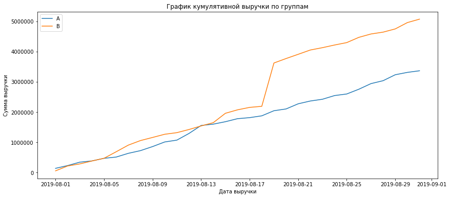

```python
# строим таблицу с датой и группой
dates_groups = orders[['date', 'group']].drop_duplicates()
# агриггируем данные по заказам по дате и группе
orders_aggregated = dates_groups.apply(
    lambda x: orders[
        np.logical_and(
            orders['date'] <= x['date'], orders['group'] == x['group']
        )
    ].agg(
        {
            'date': 'max',
            'group': 'max',
            'transaction_id': 'nunique',
            'visitor_id': 'nunique',
            'revenue': 'sum',
        }
    ),
    axis=1,
).sort_values(by=['date', 'group'])

# агриггируем данные по посещениям по дате и группе
visitors_aggregated = dates_groups.apply(
    lambda x: visitors[
        np.logical_and(
            visitors['date'] <= x['date'], visitors['group'] == x['group']
        )
    ].agg(
        {
            'date': 'max',
            'group': 'max',
            'visitors': 'sum'
        }
    ),
    axis=1,
).sort_values(by=['date', 'group'])

# объединяем полученные таблицы по заказам и посещениям
cumulative_data = orders_aggregated.merge(
    visitors_aggregated, left_on=['date', 'group'], right_on=['date', 'group']
)

# переименовываем столбцы
cumulative_data.columns = [
    'date',
    'group',
    'orders',
    'buyers',
    'revenue',
    'visitors',
]

# Отделим группу А из всей таблицы
cumulative_revenue_a = cumulative_data[cumulative_data['group']=='A'][['date','revenue', 'orders']]

# Отделим группу B из всей таблицы
cumulative_revenue_b = cumulative_data[cumulative_data['group']=='B'][['date','revenue', 'orders']]


fig = plt.figure(figsize=(14, 6)) # Размер графика

# Строим график выручки группы А
plt.plot(cumulative_revenue_a['date'], cumulative_revenue_a['revenue'], label='A')

# Строим график выручки группы B
plt.plot(cumulative_revenue_b['date'], cumulative_revenue_b['revenue'], label='B')

plt.title('График кумулятивной выручки по группам')# Заголовок графика
plt.xticks(rotation=0) # поворот подписей
#  Добавляем подписи к осям:
plt.xlabel('Дата выручки')
plt.ylabel('Сумма выручки')
plt.ticklabel_format(axis='y', style='plain', scilimits=(0,0))#  отображение оси У целым числом
plt.legend();
```

Группа В стабильно выше А, присутствует резкое увеличение выручки в районе 19 числа.

Возможно там был аномально крупный заказ или большое число заказов которые попали в группу В и повлиял на график.

## Построим график кумулятивного среднего чека по группам

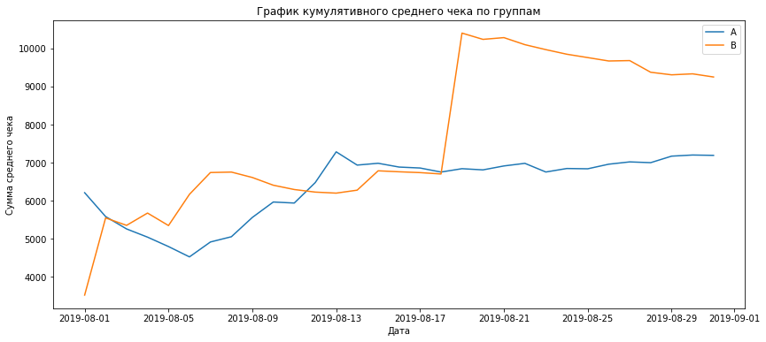

```python
fig = plt.figure(figsize=(14, 6)) # Размер графика
# Строим график среднего чека группы А
plt.plot(cumulative_revenue_a['date'], cumulative_revenue_a['revenue']/cumulative_revenue_a['orders'], label='A')
# Строим график среднего чека группы В
plt.plot(cumulative_revenue_b['date'], cumulative_revenue_b['revenue']/cumulative_revenue_b['orders'], label='B')

plt.title('График кумулятивного среднего чека по группам')# Заголовок графика
#  Добавляем подписи к осям:
plt.xlabel('Дата')
plt.ylabel('Сумма среднего чека')
plt.legend();
```

Здесь уже нет четкой лидирующей позиции группы В, в первый день группа А лидировала потом пошла на спад, но к 13 числу снова стало выше группы В и устоялась в районе 7000.

На этом графике мы также видим резкий рост 19 числа до 10000 и потом постепенное снижение среднего чека группы В к 9000. Подтверждаем догадку что в группе В был крупный заказ изменивший средний чек группы.